# Using `jrt`

## Just using `jrt` for plotting?

You may want to use `jrt` as a plotting device only. That’s ok, because `jrt` plotting functions will accept `mirt` objects as input. They should be detected automatically as such (unidimensional models only).

Let’s fit a Generalized Partial Credit Model with `mirt` for this example.

```r
fit <- mirt::mirt(data = mirt::Science,
                  model = 1,
                  itemtype = "gpcm",
                  verbose = F)
```

Now `jcc.plot()` can plot the category curves. Note that the default column names is now automatically switched to “Item”.

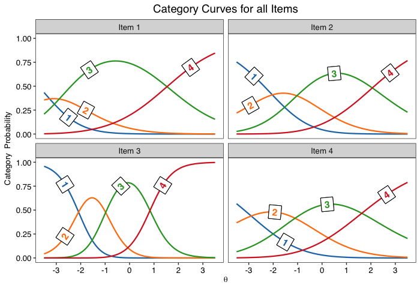

```r
jcc.plot(fit)
```

For the information plot:

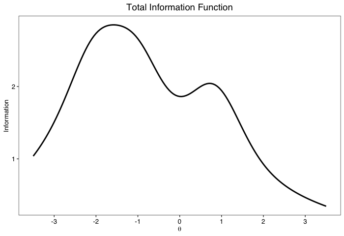

```r
info.plot(fit)
```

For convenience the argument `item` can be used instead of `judge` in both plotting functions:

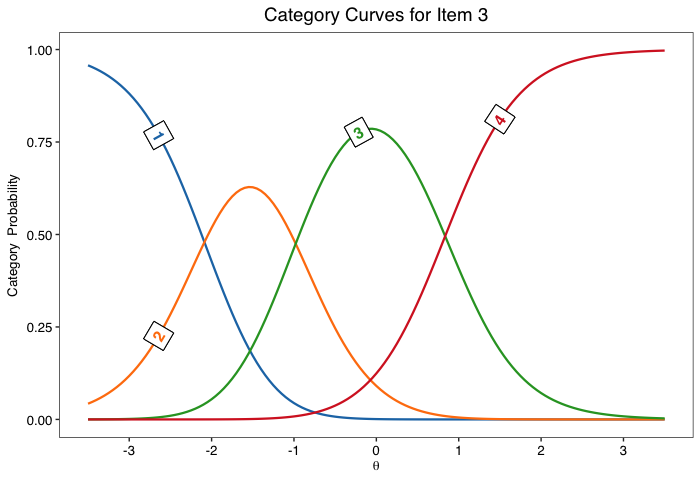

```r
jcc.plot(fit, item = 3)
```

Even though it isn’t its primary purpose, `jrt` can also plot binary item response functions. They will be automatically detected and the plot will be named accordingly.

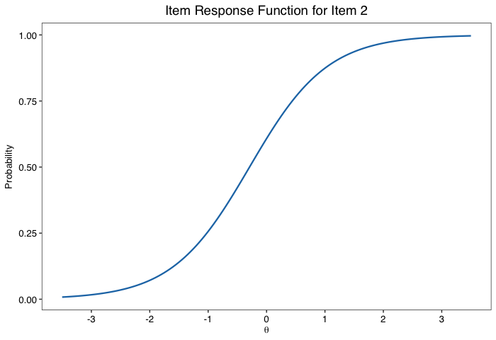

```r
# SAT data from mirt
## Convert to binary
data <- mirt::key2binary(mirt::SAT12,
    key = c(1,4,5,2,3,1,2,1,3,1,2,4,2,1,5,3,4,4,1,4,3,3,4,1,3,5,1,3,1,5,4,5))
## Fit 2PL model in mirt
fit <- mirt::mirt(data = data, model = 1, itemtype = "2PL", verbose = F)
## Plotting an item response function
jcc.plot(fit, item = 2)
```

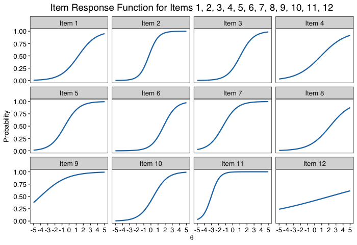

```r
## Plotting the item response functions of the first 12 items with a larger theta range
jcc.plot(fit, facet.cols = 4, item = 1:12, theta.span = 5)
```